# FPCA for partially observed functional data

Hyunsung Kim

2020-12-30

## Data generation with outliers

```r
source("pred.missfd.R")
source("simul.missfd.R")

## generate random functional data and missing periods
k <- 200   # number of grids
gr <- ((1:k)-.5)/k # equidistant grid of k points in [0,1]
n <- 200   # number of curves
m <- 20   # number of oulier curves

# generate fully observed functions
set.seed(1234)
# m different curves
x.full <- rbind(simul.fd(n=n-m, grid=gr),
                simul.fd(n=m, grid=gr, lambda.cos=1.2^(-(2*(1:300))), lambda.sin=1.2^(-(2*(1:300)-1))))

# generate observation periods
# curve 1 will be missing on (.4,.7), other curves on random subsets
x.obs <- rbind((gr<=.4)|(gr>=.7),
               simul.obs(n=n-1, grid=gr)) # TRUE if observed
# remove missing periods
x <- x.full
x[!x.obs] <- NA
```

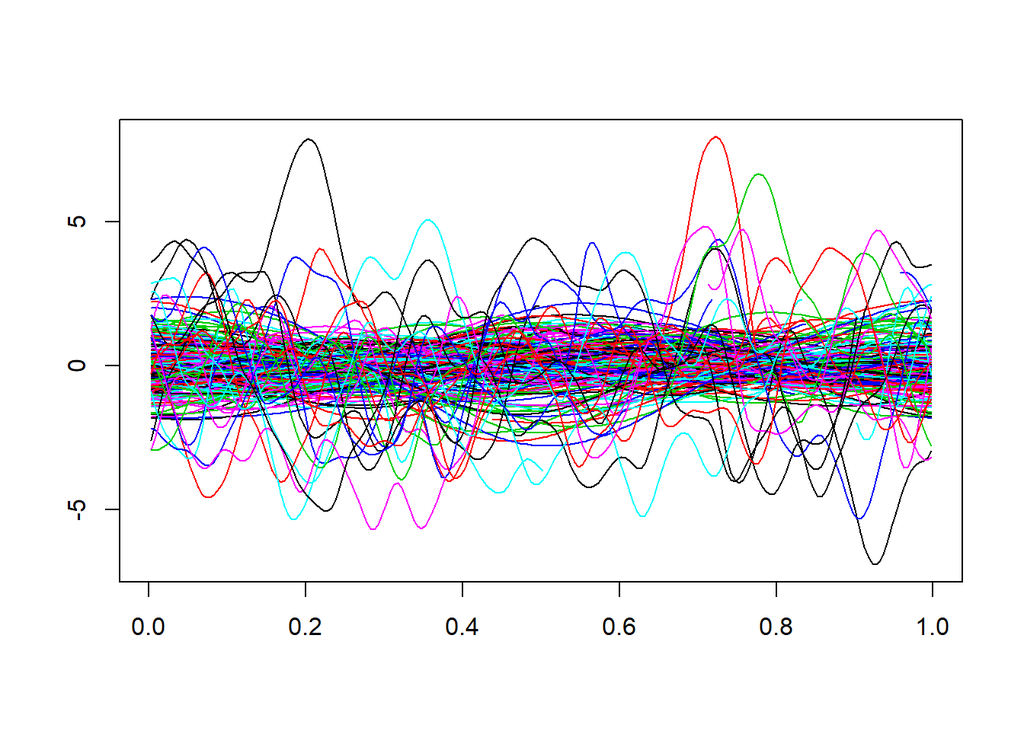

```r
# plot the functional data set
matplot(gr, t(x), type="l", lty=1, xlab="", ylab="")
```

## Comparison of 3 FPCA methods

- **Kraus** : Kraus, D. (2015). Components and completion of partially observed functional data. Journal of the Royal Statistical Society: Series B: Statistical Methodology, 777-801.
- **PACE** : Yao, F., Müller, H. G., & Wang, J. L. (2005). Functional data analysis for sparse longitudinal data. Journal of the American statistical association, 100(470), 577-590.
- **Robust** : Kraus에서 median으로 바꾼 것 (교수님께서 바꾸신 것)

```r
# transform to "sparseFPCA" and "fdapace"
x.2 <- list(x = apply(x, 1, function(y){ y[!is.na(y)] }),
            pp = apply(x.obs, 1, function(y){ gr[y] }))

# PACE
library(fdapace)
myop <- list(error=FALSE, methodXi='CE', dataType='Sparse', FVEthreshold=0.99,
             kernel='gauss', verbose=FALSE, nRegGrid=200)
pace <- FPCA(Ly=x.2$x, Lt=x.2$pp, optns=myop)   # 250 sec
```

```r
# prediction of 1st trajectory
x1.pred.kraus <- pred.missfd(x[1, ], x)
x1.pred.pace <- pace$mu + (pace$xiEst %*% t(pace$phi))[1, ]
x1.pred.pace[ x.obs[1, ] ] <- NA
x1.pred.rob <- pred.rob.missfd(x[1, ], x)
```

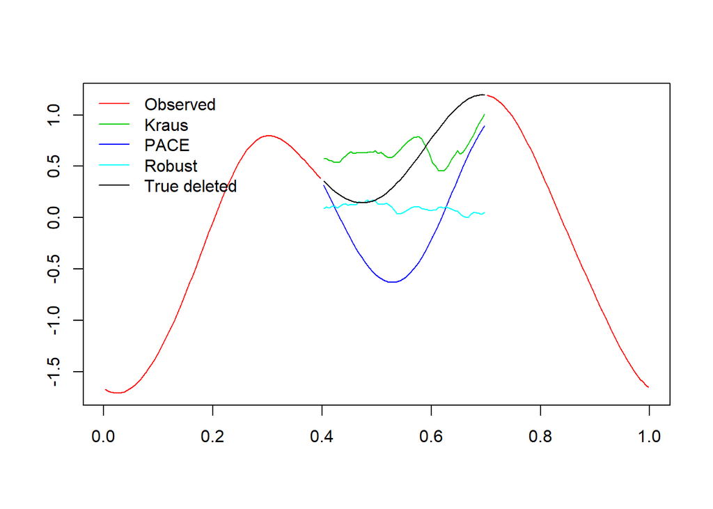

```r
# plot the observed and predicted curve and the band
matplot(gr, cbind(x[1, ], x1.pred.kraus, x1.pred.pace, x1.pred.rob),
        type="l", lty=c(1,1,1,1,1), col=c(2,3,4,5,6), xlab="", ylab="")
lines(gr[is.na(x[1, ])], x.full[1, is.na(x[1, ])], col=1)
legend("topleft", legend=c("Observed","Kraus","PACE","Robust","True deleted"),
       lty=c(1,1,1,1,1), col=c(2,3,4,5,1), bty="n")
```

## Other papers about robust FPCA

##### Boente, G., & Salibian-Barrera, M. (2015). S-estimators for functional principal component analysis. Journal of the American Statistical Association, 110(511), 1100-1111.

- - Sparse or partially observed data에 바로 적용 불가
  - [Source code](https://github.com/msalibian/S-FPCA)

##### Liebl, D., & Rameseder, S. (2019). Partially observed functional data: The case of systematically missing parts. Computational Statistics & Data Analysis, 131, 104-115.

- - 일반적인 partially observed와 다르게 마지막 부분만 censored된 데이터에 적용하는 방법론
  - [Source code](https://github.com/stefanrameseder/PartiallyFD)

##### Boente, G., & Salibian-Barrera, M. (2020). Robust functional principal components for sparse longitudinal data. arXiv preprint arXiv:2012.01540.

- - S-estimator 논문과 같은 저자의 arxiv에 업로드되어 있는 [논문](https://arxiv.org/pdf/2012.01540.pdf)
  - sparse data에 적용하는 robust FPCA 방법론
  - 코드가 공개되어 있어 비교해보려 했지만 computation 시간이 너무 오래 걸림 (10 threads로 12시간 실행했음에도 계산 안됨)
  - [Source code](https://github.com/msalibian/sparseFPCA)